# Calculating counts of gPEAs and rPEAs

Juliette Archambeau

14 novembre, 2020

In this document, we calculate the count of global and regional height-associated positive-effect alleles each genotype in each environment. Miguel et al. (2020) showed that about 350 SNPs were associated with height in maritime pine. Knowing that, we selected gPEAs and rPEAs in two ways:

- We selected all SNPs with an absolute posterior effect size larger than .006. This leads to the selection of about 350 SNPs.
- **We selected the first 350 SNPs with the largest absolute posterior effect size. This is the method that was adopted for the manuscript.**

For selected SNPs with a negative effect on height, we inverted the alleles, so that we only considered alleles with a positive effect on height when calcultating the counts.

> Load data

```r
# File with the genotype names (clone names)
geno_names <- read.delim2("../../data/ClonapinBlups523IndPiMASSJuly2019.txt", row.names=1)

# File with the genotype of each clone for each SNP
geno <- read.csv("../../data/5165snps523genotypesNA.txt", header=FALSE, row.names=1)
str(geno[,1:20])
```

```
## 'data.frame':    5165 obs. of  20 variables:
##  $ V2 : Factor w/ 4 levels "A","C","G","T": 4 4 2 3 4 3 1 3 4 3 ...
##  $ V3 : Factor w/ 4 levels "A","C","G","T": 1 2 4 1 1 1 4 1 3 2 ...
##  $ V4 : int  1 1 2 1 0 0 1 0 1 0 ...
##  $ V5 : int  0 1 2 1 0 2 1 0 1 0 ...
##  $ V6 : int  0 0 1 0 1 1 2 0 0 0 ...
##  $ V7 : int  0 0 0 2 1 2 2 0 0 0 ...
##  $ V8 : int  0 2 1 0 1 1 2 0 0 0 ...
##  $ V9 : int  2 1 0 1 0 1 2 0 0 0 ...
##  $ V10: int  0 1 2 0 0 1 1 0 0 0 ...
##  $ V11: int  0 1 1 0 0 2 1 0 1 0 ...
##  $ V12: int  0 2 1 1 0 2 2 0 1 0 ...
##  $ V13: int  0 2 1 0 0 1 2 0 1 0 ...
##  $ V14: int  1 2 1 1 0 2 2 0 0 0 ...
##  $ V15: int  0 2 0 0 0 1 2 0 0 0 ...
##  $ V16: int  0 2 2 1 0 2 2 0 0 0 ...
##  $ V17: int  1 1 1 1 0 2 2 0 0 0 ...
##  $ V18: int  1 2 0 1 0 2 2 0 0 0 ...
##  $ V19: int  1 2 1 0 0 2 2 0 0 0 ...
##  $ V20: int  1 2 1 0 0 2 2 0 0 0 ...
##  $ V21: int  1 0 0 0 1 0 0 0 1 0 ...
```

```r
dim(geno) # SNPs in rows, genotypes in columns
```

```
## [1] 5165  525
```

```r
# In this file, SNPs have their names, but not the genotypes.
head(geno[,1:10])
```

```
##          V2 V3 V4 V5 V6 V7 V8 V9 V10 V11
## SNP_0001  T  A  1  0  0  0  0  2   0   0
## SNP_0002  T  C  1  1  0  0  2  1   1   1
## SNP_0003  C  T  2  2  1  0  1  0   2   1
## SNP_0004  G  A  1  1  0  2  0  1   0   0
## SNP_0005  T  A  0  0  1  1  1  0   0   0
## SNP_0006  G  A  0  2  1  2  1  1   1   2
```

```r
# Removing the first two columns with allele info (A,T, G or C)
geno <- geno[,3:dim(geno)[[2]]]

# Give the genotype name for each column of geno
colnames(geno) <- rownames(geno_names)

rm(geno_names)

head(geno[,1:10])
```

```
##          ALT1 ALT10 ALT2 ALT3 ALT4 ALT5 ALT6 ALT8 ALT9 ARM1
## SNP_0001    1     0    0    0    0    2    0    0    0    0
## SNP_0002    1     1    0    0    2    1    1    1    2    2
## SNP_0003    2     2    1    0    1    0    2    1    1    1
## SNP_0004    1     1    0    2    0    1    0    0    1    0
## SNP_0005    0     0    1    1    1    0    0    0    0    0
## SNP_0006    0     2    1    2    1    1    1    2    2    1
```

```r
dim(geno)
```

```
## [1] 5165  523
```

There are 523 genotypes and 5,165 SNPs.

**Looking for NAs**

```r
# Total number of NAs
sum(is.na(geno))
```

```
## [1] 17263
```

```r
# Nas per rows (Number of NAs per SNPs)
na_row <- rowSums(is.na(geno))
range(na_row)
```

```
## [1]   0 142
```

```r
mean(na_row)
```

```
## [1] 3.342304
```

```r
# NAs per columns (Number of NAs per genotypes)
na_col <- colSums(is.na(geno))
range(na_col)
```

```
## [1]    7 1038
```

```r
mean(na_col)
```

```
## [1] 33.00765
```

# 1 Calculating the counts of gPEAs

## 1.1 Visualizing piMASS outupts

```r
beta.snp <- read_delim("../../data/piMASSoutputs/height_all_sites_res.mcmc.txt", "\t", escape_double = FALSE, trim_ws = TRUE)
beta.snp <- as.data.frame(beta.snp)
row.names(beta.snp) <- beta.snp$rs
beta.snp$rs <- NULL
head(beta.snp)
```

```
##          chr pos   postc  postrb     beta   betarb
## SNP_0001   0   1 0.07020 0.06725 -0.06244 -0.00285
## SNP_0002   0   2 0.04406 0.04609  0.02446  0.00072
## SNP_0003   0   3 0.06564 0.06859 -0.05948 -0.00299
## SNP_0004   0   4 0.05496 0.06070  0.04838  0.00207
## SNP_0005   0   5 0.06971 0.07385 -0.06782 -0.00348
## SNP_0006   0   6 0.12131 0.14394 -0.10956 -0.01072
```

```r
# Checking that the genotypes names in the two files are the same,
# and are ranked similarly.
compare::compare(row.names(beta.snp),row.names(geno))
```

```
## TRUE
```

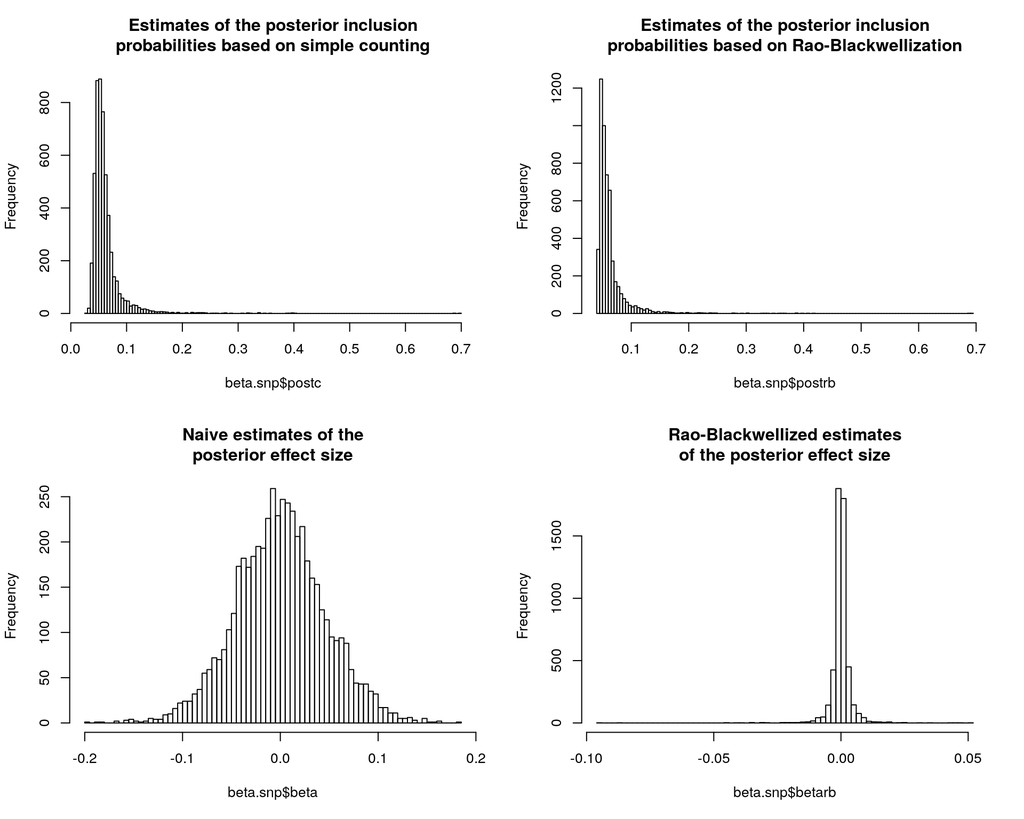

> Posterior inclusion probabilities

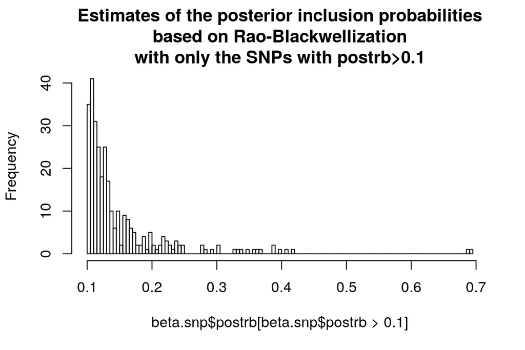

Below are the estimates of the posterior inclusion probabilities based on Rao-Blackwellization with the four SNPs with **postrb>0.4**.

```r
beta.snp[abs(beta.snp$postrb)>0.4|abs(beta.snp$postrb)==0.4,]
```

```
##          chr  pos   postc  postrb     beta   betarb
## SNP_0129   0  126 0.40248 0.41565  0.18055  0.05161
## SNP_4437   0 3653 0.69681 0.68601 -0.18143 -0.08790
## SNP_4540   0 3751 0.39937 0.40827  0.16129  0.04706
## SNP_5338   0 4454 0.68861 0.69081 -0.19751 -0.09509
```

> Posterior effect sizes

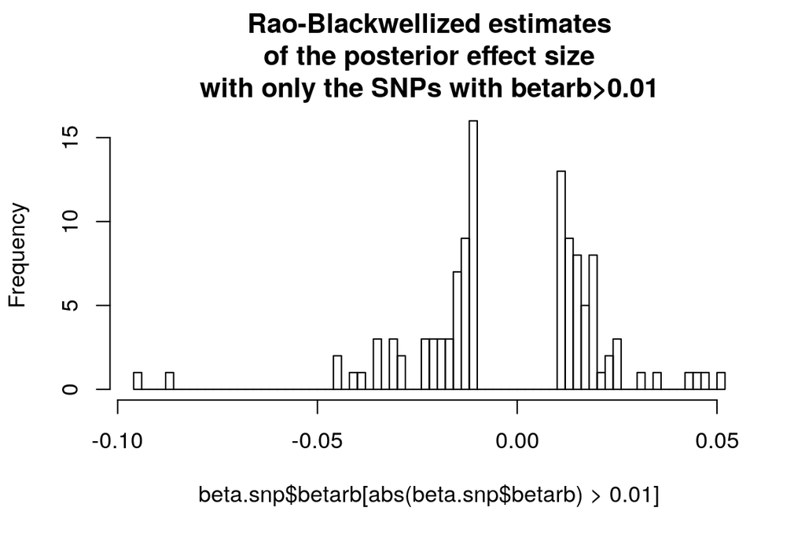

Below are the Rao-Blackwellized estimates the posterior effect size with the three SNPs with **betarb>0.05**.

```r
beta.snp[abs(beta.snp$betarb)>0.05|abs(beta.snp$betarb)==0.05,]
```

```
##          chr  pos   postc  postrb     beta   betarb
## SNP_0129   0  126 0.40248 0.41565  0.18055  0.05161
## SNP_4437   0 3653 0.69681 0.68601 -0.18143 -0.08790
## SNP_5338   0 4454 0.68861 0.69081 -0.19751 -0.09509
```

## 1.2 Selecting gPEAs (with betarb>0.006)

```r
# SNPs associated with height (with posterior effect size higher than 0.006)
snps.h <- beta.snp[abs(beta.snp$betarb)>0.006|abs(beta.snp$betarb)==0.006,]
length(snps.h$chr)
```

```
## [1] 322
```

```r
# Among the selected SNPs, SNPs positively associated with height:
snps.h.pos <- row.names(snps.h[snps.h$betarb>0,])
length(snps.h.pos)
```

```
## [1] 174
```

```r
# Among the selected SNPs, SNPs negatively associated with height:
snps.h.neg <- row.names(snps.h[snps.h$betarb<0,])
length(snps.h.neg)
```

```
## [1] 148
```

```r
# Subset of alleles with positive effect on height
geno.snp.h.pos <- geno[row.names(geno) %in% snps.h.pos,]
geno.snp.h.pos[1:5,1:5]
```

```
##          ALT1 ALT10 ALT2 ALT3 ALT4
## SNP_0050    0     1    0    0    0
## SNP_0103    1     1    1    2    1
## SNP_0129    0     0    1    0    0
## SNP_0147    2     0    0    1    0
## SNP_0184    2     1    1    0    0
```

```r
# Subset of alleles with negative effect on height
geno.snp.h.neg <- geno[row.names(geno) %in% snps.h.neg,]
geno.snp.h.neg[1:5,1:5]
```

```
##          ALT1 ALT10 ALT2 ALT3 ALT4
## SNP_0006    0     2    1    2    1
## SNP_0020    0     0    0    0    0
## SNP_0028    1     0    0    1    0
## SNP_0057    0     1    1    2    1
## SNP_0082    0     0    0    0    0
```

```r
# Inverting 0 and 2 in the subset of alleles with negative effects,
# to only have alleles with a positive effect
snpnames <- row.names(geno.snp.h.neg)
geno.snp.h.neg <- geno.snp.h.neg %>%  mutate_if(is.integer, as.numeric) %>% mutate_all(list(~recode(., `0` = 2,`2`=0)))
row.names(geno.snp.h.neg) <- snpnames
geno.snp.h.neg[1:5,1:5]
```

```
##          ALT1 ALT10 ALT2 ALT3 ALT4
## SNP_0006    2     0    1    0    1
## SNP_0020    2     2    2    2    2
## SNP_0028    1     2    2    1    2
## SNP_0057    2     1    1    0    1
## SNP_0082    2     2    2    2    2
```

```r
# combining positive and negative alleles
geno.snp.h <-rbind(geno.snp.h.pos,geno.snp.h.neg)
geno.snp.h[1:5,1:5]
```

```
##          ALT1 ALT10 ALT2 ALT3 ALT4
## SNP_0050    0     1    0    0    0
## SNP_0103    1     1    1    2    1
## SNP_0129    0     0    1    0    0
## SNP_0147    2     0    0    1    0
## SNP_0184    2     1    1    0    0
```

```r
DF <- data.frame(clon=names(geno.snp.h),count_all_006=apply(geno.snp.h,2,sum,na.rm=T))

var(DF$count_all_006)
```

```
## [1] 678.6061
```

```r
range(DF$count_all_006)
```

```
## [1] 231 382
```

```r
mean(DF$count_all_006)
```

```
## [1] 301.6539
```

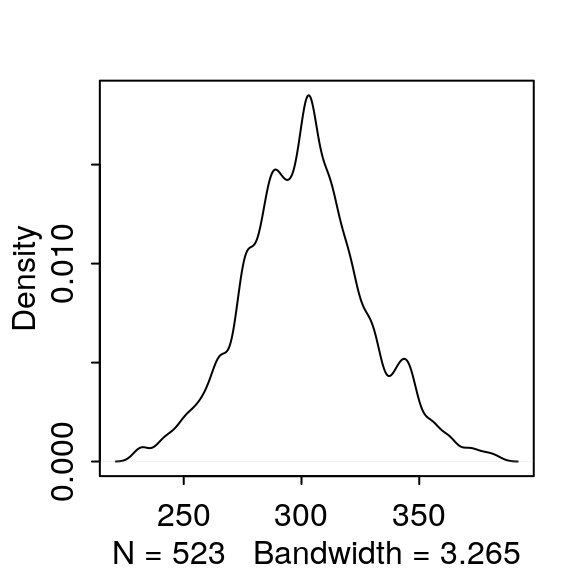

```r
rethinking::dens(DF$count_all_006)
```

## 1.3 Selecting gPEAs (first 350 SNPs)

```r
# Snps associated with height
beta.snp.order <- beta.snp[order(abs(beta.snp$betarb),decreasing=T),]
beta.snp.order350 <- beta.snp.order[1:350,]
length(beta.snp.order350$beta)
```

```
## [1] 350
```

```r
# Snps positively associated with height
snps.h.pos.350 <- row.names(beta.snp.order350[beta.snp.order350$betarb>0,])
length(snps.h.pos.350)
```

```
## [1] 186
```

```r
# Snps negatively associated with height
snps.h.neg.350 <- row.names(beta.snp.order350[beta.snp.order350$betarb<0,])
length(snps.h.neg.350)
```

```
## [1] 164
```

```r
# Subset of alleles with positive effect on height
geno.snp.h.pos.350 <- geno[row.names(geno) %in% snps.h.pos.350,]
geno.snp.h.pos.350[1:5,1:5]
```

```
##          ALT1 ALT10 ALT2 ALT3 ALT4
## SNP_0050    0     1    0    0    0
## SNP_0103    1     1    1    2    1
## SNP_0129    0     0    1    0    0
## SNP_0147    2     0    0    1    0
## SNP_0184    2     1    1    0    0
```

```r
# Subset of alleles with negative effect on height
geno.snp.h.neg.350 <- geno[row.names(geno) %in% snps.h.neg.350,]
geno.snp.h.neg.350[1:5,1:5]
```

```
##          ALT1 ALT10 ALT2 ALT3 ALT4
## SNP_0006    0     2    1    2    1
## SNP_0020    0     0    0    0    0
## SNP_0028    1     0    0    1    0
## SNP_0057    0     1    1    2    1
## SNP_0082    0     0    0    0    0
```

```r
# Inverting 0 and 2 in the subset of alleles with negative effects,
# to only have alleles with a positive effect
snpnames <- row.names(geno.snp.h.neg.350)
geno.snp.h.neg.350 <- geno.snp.h.neg.350 %>%  mutate_if(is.integer, as.numeric) %>% mutate_all(list(~recode(., `0` = 2,`2`=0)))
row.names(geno.snp.h.neg.350) <- snpnames
geno.snp.h.neg.350[1:5,1:5]
```

```
##          ALT1 ALT10 ALT2 ALT3 ALT4
## SNP_0006    2     0    1    0    1
## SNP_0020    2     2    2    2    2
## SNP_0028    1     2    2    1    2
## SNP_0057    2     1    1    0    1
## SNP_0082    2     2    2    2    2
```

```r
# combining positive and negative alleles
geno.snp.h.350 <-rbind(geno.snp.h.pos.350,geno.snp.h.neg.350)
names.all <- rownames(geno.snp.h.350)

df <- data.frame(clon=names(geno.snp.h.350),count_all_350=apply(geno.snp.h.350,2,sum,na.rm=T))

var(df$count_all_350)
```

```
## [1] 751.2744
```

```r
range(df$count_all_350)
```

```
## [1] 254 416
```

```r
mean(df$count_all_350)
```

```
## [1] 330.6348
```

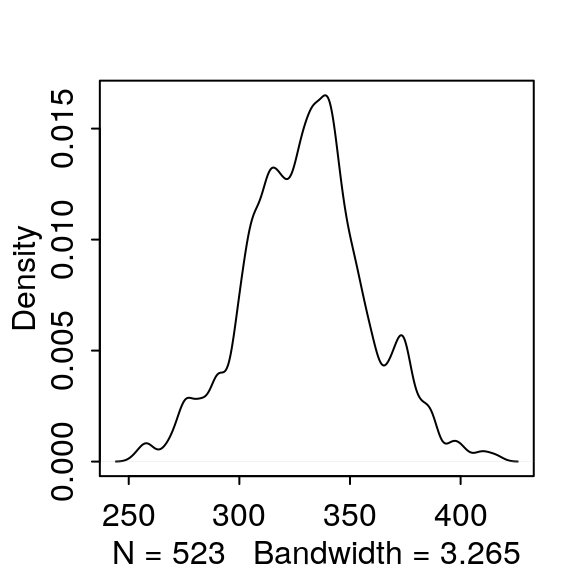

```r
rethinking::dens(df$count_all_350)
```

```r
DF <- merge(DF,df,by="clon")
head(DF)
```

```
##    clon count_all_006 count_all_350
## 1  ALT1           312           343
## 2 ALT10           295           322
## 3  ALT2           288           314
## 4  ALT3           316           340
## 5  ALT4           291           318
## 6  ALT5           314           343
```

# 2 Calculate the regional counts of rPEAs

## 2.1 In the French Atlantic region

### 2.1.1 Visualizing piMASS outupts

```r
beta.snp <- read_delim("../../../data/raw-data/res_analyses-max2000_31072019/height_french_atlantic_res.mcmc.txt", "\t", escape_double = FALSE, trim_ws = TRUE)
beta.snp <- as.data.frame(beta.snp)
row.names(beta.snp) <- beta.snp$rs
beta.snp$rs <- NULL
head(beta.snp)
```

```
##          chr pos   postc  postrb     beta   betarb
## SNP_0001   0   1 0.04853 0.05422 -0.02308 -0.00086
## SNP_0002   0   2 0.07179 0.06434  0.05432  0.00211
## SNP_0003   0   3 0.06602 0.06299 -0.05347 -0.00207
## SNP_0004   0   4 0.06759 0.06088  0.02943  0.00121
## SNP_0005   0   5 0.06119 0.05786 -0.02859 -0.00119
## SNP_0006   0   6 0.19183 0.19546 -0.13039 -0.01676
```

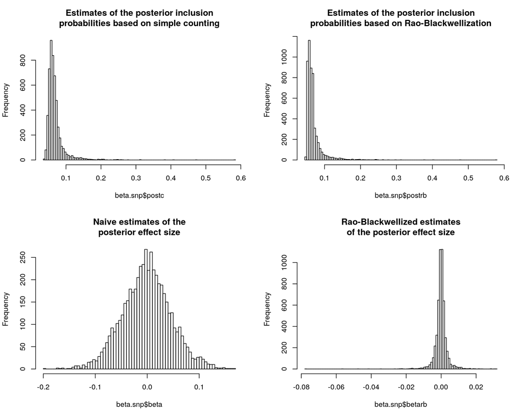

> Posterior inclusion probabilities

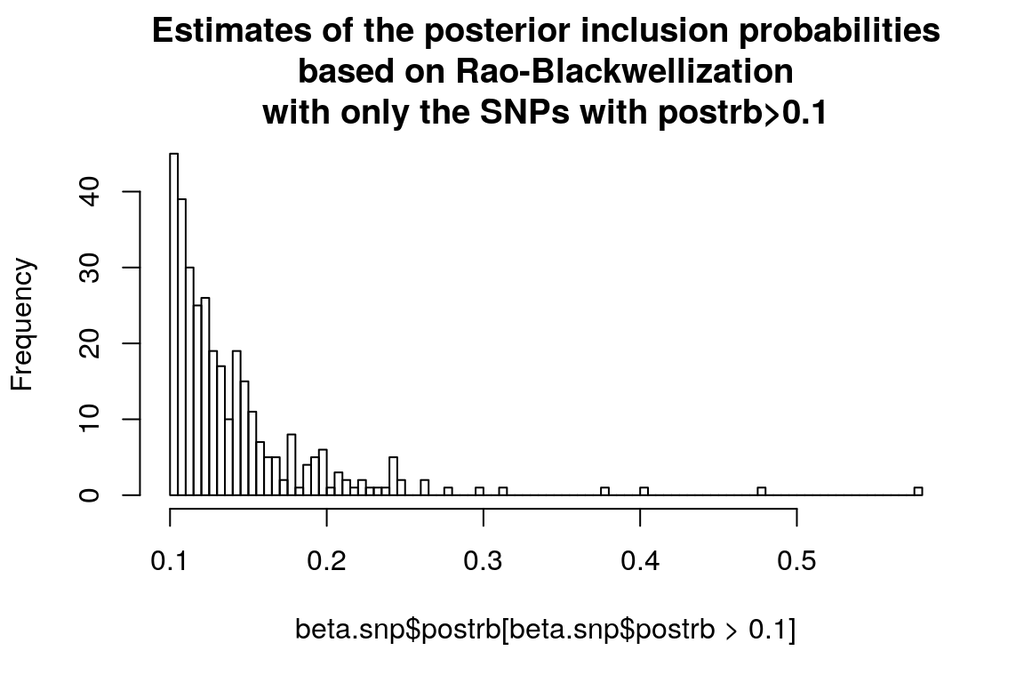

Below are the estimates of the posterior inclusion probabilities based on Rao-Blackwellization with the three SNPs with **postrb>0.4**.

```r
beta.snp[abs(beta.snp$postrb)>0.4|abs(beta.snp$postrb)==0.4,]
```

```
##          chr  pos   postc  postrb     beta   betarb
## SNP_0057   0   54 0.58326 0.57841 -0.19912 -0.07707
## SNP_4437   0 3653 0.47410 0.47544 -0.17283 -0.05612
## SNP_5338   0 4454 0.40532 0.40404 -0.17395 -0.04729
```

> Posterior effect sizes

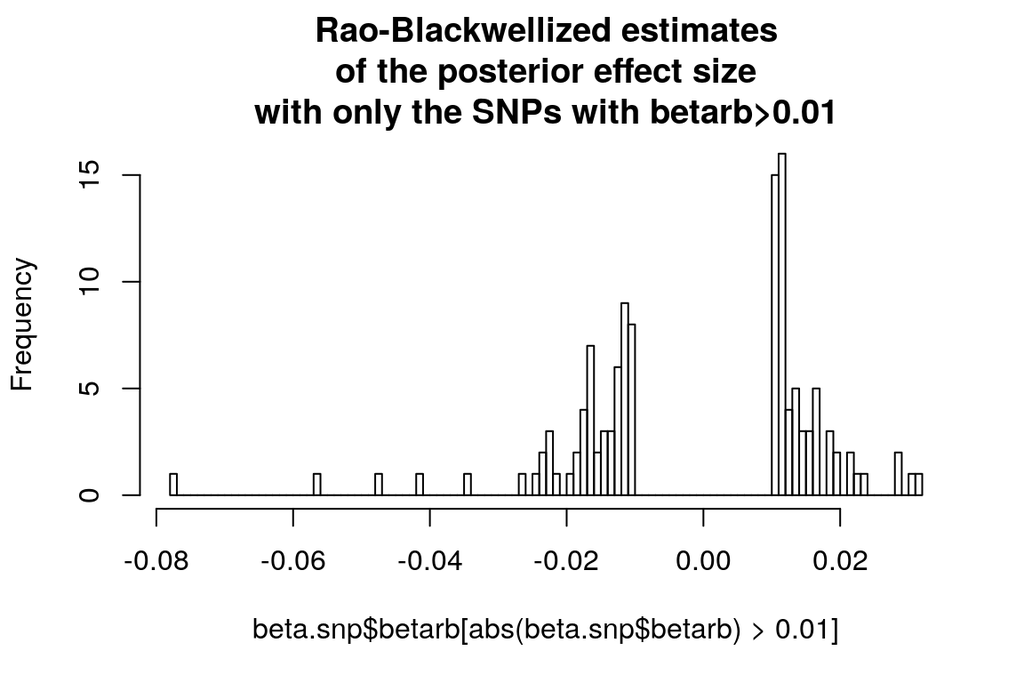

Below are the Rao-Blackwellized estimates the posterior effect size with the two SNPs with **betarb>0.05**.

```r
beta.snp[abs(beta.snp$betarb)>0.05|abs(beta.snp$betarb)==0.05,]
```

```
##          chr  pos   postc  postrb     beta   betarb
## SNP_0057   0   54 0.58326 0.57841 -0.19912 -0.07707
## SNP_4437   0 3653 0.47410 0.47544 -0.17283 -0.05612
```

### 2.1.2 Selecting rPEAs (betarb>0.006)

```r
# Snps associated with height
snps.h <- beta.snp[abs(beta.snp$betarb)>0.006|abs(beta.snp$betarb)==0.006,]
length(snps.h$chr)
```

```
## [1] 321
```

```r
# Snps positively associated with height
snps.h.pos <- row.names(snps.h[snps.h$betarb>0,])
length(snps.h.pos)
```

```
## [1] 164
```

```r
# Snps negatively associated with height
snps.h.neg <- row.names(snps.h[snps.h$betarb<0,])
length(snps.h.neg)
```

```
## [1] 157
```

```r
# Subset of alleles with positive effect on height
geno.snp.h.pos <- geno[row.names(geno) %in% snps.h.pos,]
geno.snp.h.pos[1:5,1:5]
```

```
##          ALT1 ALT10 ALT2 ALT3 ALT4
## SNP_0090    1     0    1    1    2
## SNP_0103    1     1    1    2    1
## SNP_0129    0     0    1    0    0
## SNP_0147    2     0    0    1    0
## SNP_0184    2     1    1    0    0
```

```r
# Subset of alleles with negative effect on height
geno.snp.h.neg <- geno[row.names(geno) %in% snps.h.neg,]
geno.snp.h.neg[1:5,1:5]
```

```
##          ALT1 ALT10 ALT2 ALT3 ALT4
## SNP_0006    0     2    1    2    1
## SNP_0057    0     1    1    2    1
## SNP_0082    0     0    0    0    0
## SNP_0107    0     2    0    0    0
## SNP_0130    0     1    0    0    0
```

```r
# Inverting 0 and 2 in the subset of alleles with negative effects,
# to only have alleles with a positive effect
snpnames <- row.names(geno.snp.h.neg)
geno.snp.h.neg <- geno.snp.h.neg %>%  mutate_if(is.integer, as.numeric) %>% mutate_all(list(~recode(., `0` = 2,`2`=0)))
row.names(geno.snp.h.neg) <- snpnames
geno.snp.h.neg[1:5,1:5]
```

```
##          ALT1 ALT10 ALT2 ALT3 ALT4
## SNP_0006    2     0    1    0    1
## SNP_0057    2     1    1    0    1
## SNP_0082    2     2    2    2    2
## SNP_0107    2     0    2    2    2
## SNP_0130    2     1    2    2    2
```

```r
# combining positive and negative alleles
geno.snp.h <-rbind(geno.snp.h.pos,geno.snp.h.neg)

df <- data.frame(clon=names(geno.snp.h),count_fratl_006=apply(geno.snp.h,2,sum,na.rm=T))

var(df$count_fratl_006)
```

```
## [1] 672.6644
```

```r
range(df$count_fratl_006)
```

```
## [1] 227 373
```

```r
mean(df$count_fratl_006)
```

```
## [1] 299.7763
```

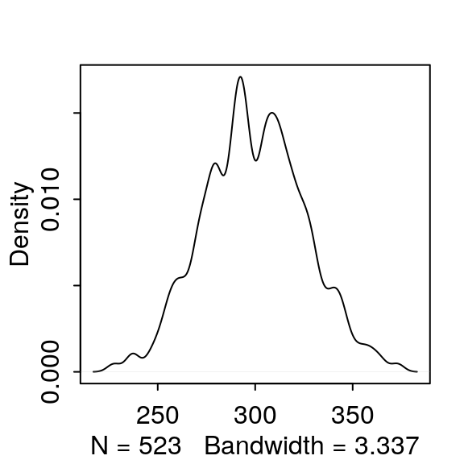

```r
rethinking::dens(df$count_fratl_006)
```

```r
DF <- merge(DF,df,by="clon")
head(DF)
```

```
##    clon count_all_006 count_all_350 count_fratl_006
## 1  ALT1           312           343             280
## 2 ALT10           295           322             297
## 3  ALT2           288           314             290
## 4  ALT3           316           340             266
## 5  ALT4           291           318             262
## 6  ALT5           314           343             305
```

### 2.1.3 Selecting rPEAs (first 350 SNPs)

```r
# Snps associated with height
beta.snp.order <- beta.snp[order(abs(beta.snp$betarb),decreasing=T),]
beta.snp.order350 <- beta.snp.order[1:350,]
length(beta.snp.order350$beta)
```

```
## [1] 350
```

```r
# Snps positively associated with height
snps.h.pos.350 <- row.names(beta.snp.order350[beta.snp.order350$betarb>0,])
length(snps.h.pos.350)
```

```
## [1] 177
```

```r
# Snps negatively associated with height
snps.h.neg.350 <- row.names(beta.snp.order350[beta.snp.order350$betarb<0,])
length(snps.h.neg.350)
```

```
## [1] 173
```

```r
# Subset of alleles with positive effect on height
geno.snp.h.pos.350 <- geno[row.names(geno) %in% snps.h.pos.350,]

# Subset of alleles with negative effect on height
geno.snp.h.neg.350 <- geno[row.names(geno) %in% snps.h.neg.350,]
geno.snp.h.neg.350[1:5,1:5]
```

```
##          ALT1 ALT10 ALT2 ALT3 ALT4
## SNP_0006    0     2    1    2    1
## SNP_0057    0     1    1    2    1
## SNP_0082    0     0    0    0    0
## SNP_0107    0     2    0    0    0
## SNP_0130    0     1    0    0    0
```

```r
# Inverting 0 and 2 in the subset of alleles with negative effects,
# to only have alleles with a positive effect
snpnames <- row.names(geno.snp.h.neg.350)
geno.snp.h.neg.350 <- geno.snp.h.neg.350 %>%  mutate_if(is.integer, as.numeric) %>% mutate_all(list(~recode(., `0` = 2,`2`=0)))
row.names(geno.snp.h.neg.350) <- snpnames
geno.snp.h.neg.350[1:5,1:5]
```

```
##          ALT1 ALT10 ALT2 ALT3 ALT4
## SNP_0006    2     0    1    0    1
## SNP_0057    2     1    1    0    1
## SNP_0082    2     2    2    2    2
## SNP_0107    2     0    2    2    2
## SNP_0130    2     1    2    2    2
```

```r
# combining positive and negative alleles
geno.snp.h.350 <-rbind(geno.snp.h.pos.350,geno.snp.h.neg.350)
names.fr_atl <- rownames(geno.snp.h.350)

df <- data.frame(clon=names(geno.snp.h.350),count_fratl_350=apply(geno.snp.h.350,2,sum,na.rm=T))

var(df$count_fratl_350)
```

```
## [1] 759.1742
```

```r
range(df$count_fratl_350)
```

```
## [1] 253 411
```

```r
mean(df$count_fratl_350)
```

```
## [1] 329.9866
```

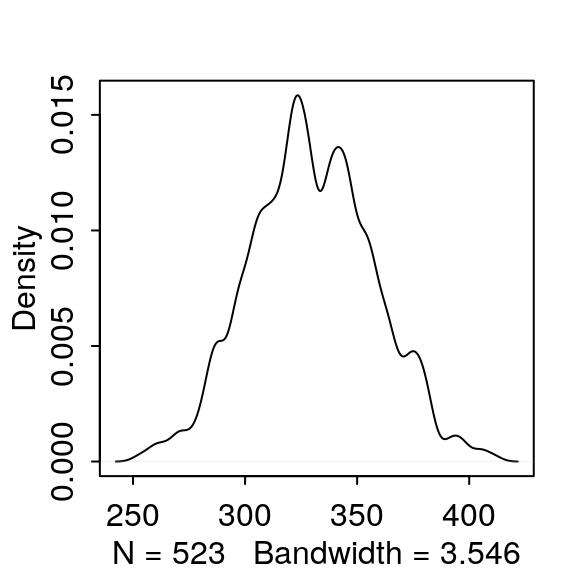

```r
rethinking::dens(df$count_fratl_350)
```

```r
DF <- merge(DF,df,by="clon")
head(DF)
```

```
##    clon count_all_006 count_all_350 count_fratl_006 count_fratl_350
## 1  ALT1           312           343             280             313
## 2 ALT10           295           322             297             330
## 3  ALT2           288           314             290             314
## 4  ALT3           316           340             266             293
## 5  ALT4           291           318             262             290
## 6  ALT5           314           343             305             330
```

## 2.2 In the Iberian Atlantic region

### 2.2.1 Visualizing piMASS outupts

```r
beta.snp <- read_delim("../../../data/raw-data/res_analyses-max2000_31072019/height_iberian_atlantic_res.mcmc.txt", "\t",
                       escape_double = FALSE, trim_ws = TRUE)
beta.snp <- as.data.frame(beta.snp)
row.names(beta.snp) <- beta.snp$rs
beta.snp$rs <- NULL
head(beta.snp)
```

```
##          chr pos   postc  postrb     beta   betarb
## SNP_0001   0   1 0.07661 0.07143 -0.05267 -0.00249
## SNP_0002   0   2 0.06227 0.06275  0.03480  0.00144
## SNP_0003   0   3 0.06868 0.06374 -0.04372 -0.00175
## SNP_0004   0   4 0.07668 0.08004  0.06319  0.00320
## SNP_0005   0   5 0.07799 0.07365 -0.05505 -0.00264
## SNP_0006   0   6 0.11478 0.10648 -0.08415 -0.00582
```

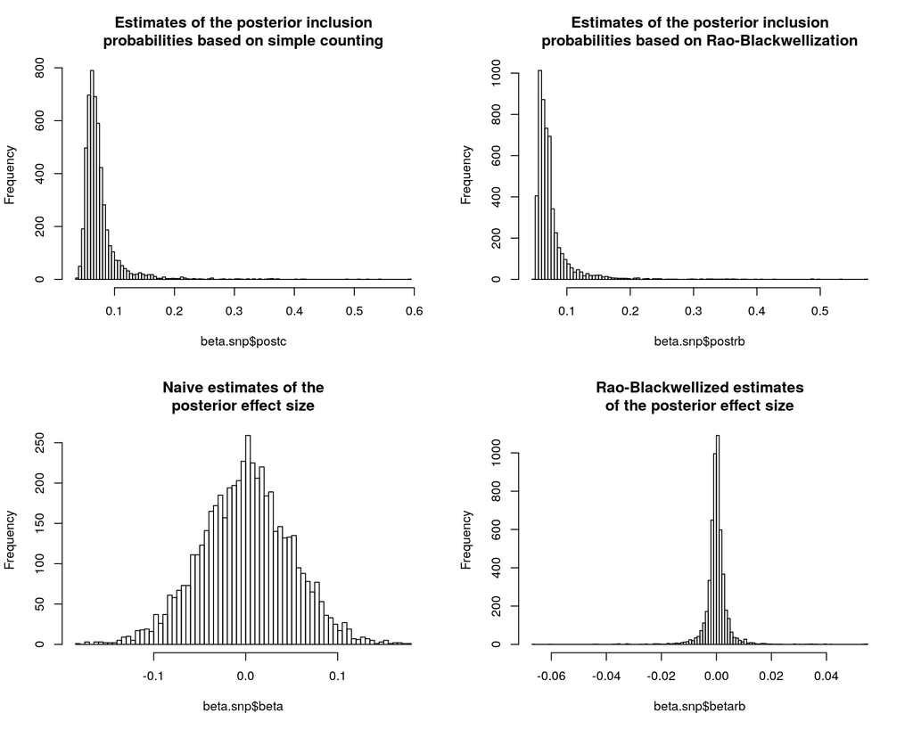

> Posterior inclusion probabilities

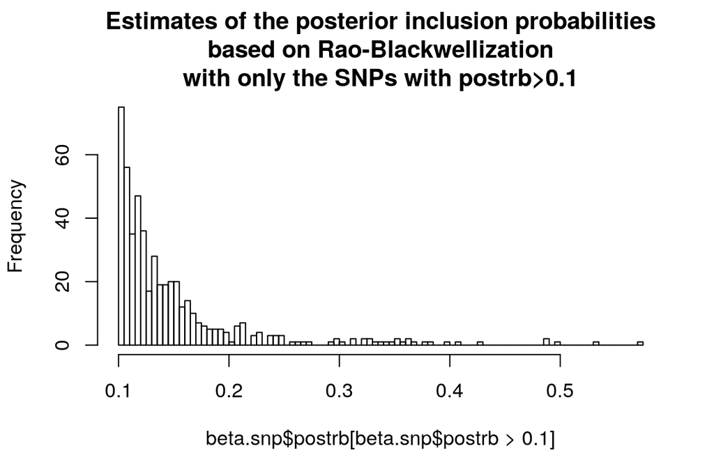

```r
beta.snp[abs(beta.snp$postrb)>0.4|abs(beta.snp$postrb)==0.4,]
```

```
##          chr  pos   postc  postrb     beta   betarb
## SNP_0956   0  751 0.48984 0.49985  0.16912  0.05451
## SNP_3819   0 3152 0.54334 0.53284 -0.17445 -0.06009
## SNP_4511   0 3723 0.50642 0.48970  0.16747  0.05319
## SNP_5180   0 4313 0.41718 0.40886 -0.16461 -0.04455
## SNP_5327   0 4443 0.41026 0.42637 -0.16306 -0.04384
## SNP_5338   0 4454 0.59338 0.57113 -0.18065 -0.06660
## SNP_5650   0 4745 0.52302 0.48540  0.17362  0.05412
```

> Posterior effect sizes

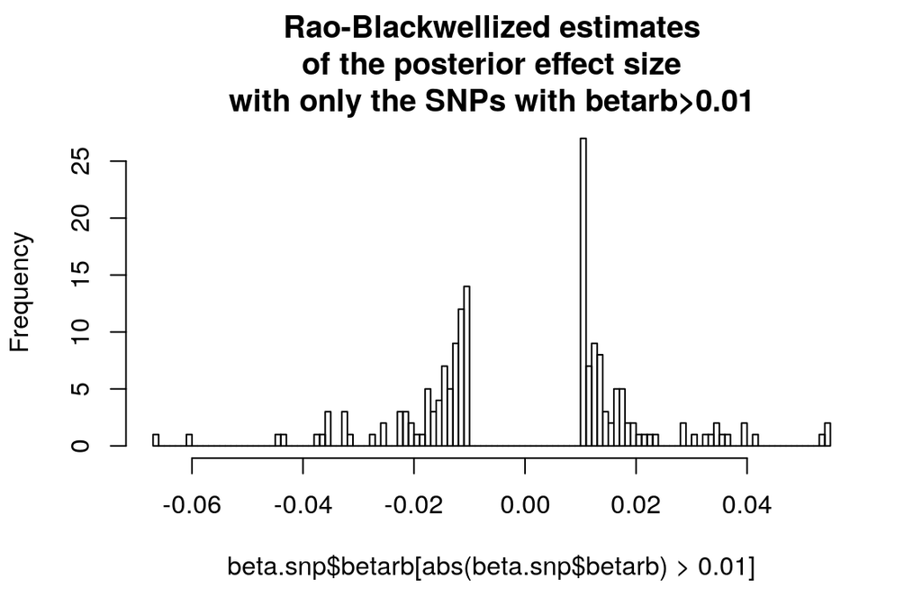

```r
beta.snp[abs(beta.snp$betarb)>0.05|abs(beta.snp$betarb)==0.05,]
```

```
##          chr  pos   postc  postrb     beta   betarb
## SNP_0956   0  751 0.48984 0.49985  0.16912  0.05451
## SNP_3819   0 3152 0.54334 0.53284 -0.17445 -0.06009
## SNP_4511   0 3723 0.50642 0.48970  0.16747  0.05319
## SNP_5338   0 4454 0.59338 0.57113 -0.18065 -0.06660
## SNP_5650   0 4745 0.52302 0.48540  0.17362  0.05412
```

### 2.2.2 Selecting rPEAS (betarb>0.006)

```r
# Snps associated with height
snps.h <- beta.snp[abs(beta.snp$betarb)>0.006|abs(beta.snp$betarb)==0.006,]
length(snps.h$chr)
```

```
## [1] 396
```

```r
# Snps positively associated with height
snps.h.pos <- row.names(snps.h[snps.h$betarb>0,])
length(snps.h.pos)
```

```
## [1] 192
```

```r
# Snps negatively associated with height
snps.h.neg <- row.names(snps.h[snps.h$betarb<0,])
length(snps.h.neg)
```

```
## [1] 204
```

```r
# Subset of alleles with positive effect on height
geno.snp.h.pos <- geno[row.names(geno) %in% snps.h.pos,]
geno.snp.h.pos[1:5,1:5]
```

```
##          ALT1 ALT10 ALT2 ALT3 ALT4
## SNP_0032    1     1    1    0    2
## SNP_0033    0     0    0    0    0
## SNP_0049    0     1    0    1    0
## SNP_0050    0     1    0    0    0
## SNP_0129    0     0    1    0    0
```

```r
# Subset of alleles with negative effect on height
geno.snp.h.neg <- geno[row.names(geno) %in% snps.h.neg,]
geno.snp.h.neg[1:5,1:5]
```

```
##          ALT1 ALT10 ALT2 ALT3 ALT4
## SNP_0020    0     0    0    0    0
## SNP_0028    1     0    0    1    0
## SNP_0083    0     0    0    0    0
## SNP_0162    1     1    0    0    1
## SNP_0180    0     1    2    2    1
```

```r
# Inverting 0 and 2 in the subset of alleles with negative effects,
# to only have alleles with a positive effect
snpnames <- row.names(geno.snp.h.neg)
geno.snp.h.neg <- geno.snp.h.neg %>%  mutate_if(is.integer, as.numeric) %>% mutate_all(list(~recode(., `0` = 2,`2`=0)))
row.names(geno.snp.h.neg) <- snpnames
geno.snp.h.neg[1:5,1:5]
```

```
##          ALT1 ALT10 ALT2 ALT3 ALT4
## SNP_0020    2     2    2    2    2
## SNP_0028    1     2    2    1    2
## SNP_0083    2     2    2    2    2
## SNP_0162    1     1    2    2    1
## SNP_0180    2     1    0    0    1
```

```r
# combining positive and negative alleles
geno.snp.h <-rbind(geno.snp.h.pos,geno.snp.h.neg)

df <- data.frame(clon=names(geno.snp.h),count_ibatl_006=apply(geno.snp.h,2,sum,na.rm=T))

var(df$count_ibatl_006)
```

```
## [1] 863.1422
```

```r
range(df$count_ibatl_006)
```

```
## [1] 304 486
```

```r
mean(df$count_ibatl_006)
```

```
## [1] 407.4073
```

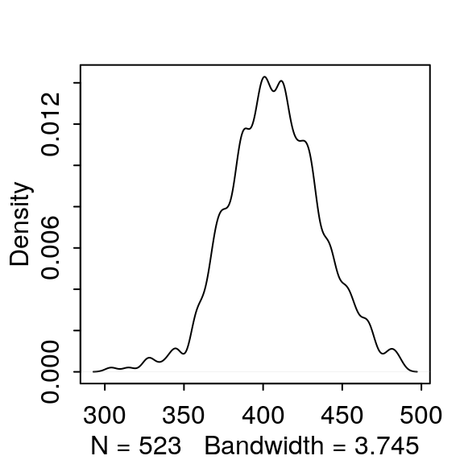

```r
rethinking::dens(df$count_ibatl_006)
```

```r
DF <- merge(DF,df,by="clon")
head(DF)
```

```
##    clon count_all_006 count_all_350 count_fratl_006 count_fratl_350 count_ibatl_006
## 1  ALT1           312           343             280             313             423
## 2 ALT10           295           322             297             330             409
## 3  ALT2           288           314             290             314             423
## 4  ALT3           316           340             266             293             413
## 5  ALT4           291           318             262             290             425
## 6  ALT5           314           343             305             330             428
```

### 2.2.3 Selecting rPEAs (first 350 SNPs)

```r
# Snps associated with height
beta.snp.order <- beta.snp[order(abs(beta.snp$betarb),decreasing=T),]
beta.snp.order350 <- beta.snp.order[1:350,]
length(beta.snp.order350$beta)
```

```
## [1] 350
```

```r
# Snps positively associated with height
snps.h.pos.350 <- row.names(beta.snp.order350[beta.snp.order350$betarb>0,])
length(snps.h.pos.350)
```

```
## [1] 169
```

```r
# Snps negatively associated with height
snps.h.neg.350 <- row.names(beta.snp.order350[beta.snp.order350$betarb<0,])
length(snps.h.neg.350)
```

```
## [1] 181
```

```r
# Subset of alleles with positive effect on height
geno.snp.h.pos.350 <- geno[row.names(geno) %in% snps.h.pos.350,]
geno.snp.h.pos.350[1:5,1:5]
```

```
##          ALT1 ALT10 ALT2 ALT3 ALT4
## SNP_0032    1     1    1    0    2
## SNP_0033    0     0    0    0    0
## SNP_0049    0     1    0    1    0
## SNP_0050    0     1    0    0    0
## SNP_0129    0     0    1    0    0
```

```r
# Subset of alleles with negative effect on height
geno.snp.h.neg.350 <- geno[row.names(geno) %in% snps.h.neg.350,]
geno.snp.h.neg.350[1:5,1:5]
```

```
##          ALT1 ALT10 ALT2 ALT3 ALT4
## SNP_0020    0     0    0    0    0
## SNP_0028    1     0    0    1    0
## SNP_0162    1     1    0    0    1
## SNP_0180    0     1    2    2    1
## SNP_0286    0     0    0    1    0
```

```r
# Inverting 0 and 2 in the subset of alleles with negative effects,
# to only have alleles with a positive effect
snpnames <- row.names(geno.snp.h.neg.350)
geno.snp.h.neg.350 <- geno.snp.h.neg.350 %>%  mutate_if(is.integer, as.numeric) %>% mutate_all(list(~recode(., `0` = 2,`2`=0)))
row.names(geno.snp.h.neg.350) <- snpnames
geno.snp.h.neg.350[1:5,1:5]
```

```
##          ALT1 ALT10 ALT2 ALT3 ALT4
## SNP_0020    2     2    2    2    2
## SNP_0028    1     2    2    1    2
## SNP_0162    1     1    2    2    1
## SNP_0180    2     1    0    0    1
## SNP_0286    2     2    2    1    2
```

```r
# combining positive and negative alleles
geno.snp.h.350 <-rbind(geno.snp.h.pos.350,geno.snp.h.neg.350)
names.ib_atl <- rownames(geno.snp.h.350)

df <- data.frame(clon=names(geno.snp.h.350),count_ibatl_350=apply(geno.snp.h.350,2,sum,na.rm=T))

var(df$count_ibatl_350)
```

```
## [1] 705.8725
```

```r
range(df$count_ibatl_350)
```

```
## [1] 275 434
```

```r
mean(df$count_ibatl_350)
```

```
## [1] 362.7878
```

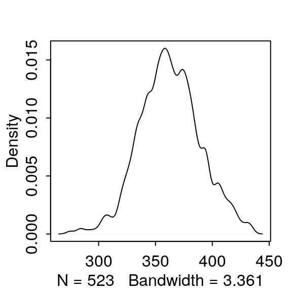

```r
rethinking::dens(df$count_ibatl_350)
```

```r
DF <- merge(DF,df,by="clon")
head(DF)
```

```
##    clon count_all_006 count_all_350 count_fratl_006 count_fratl_350 count_ibatl_006 count_ibatl_350
## 1  ALT1           312           343             280             313             423             373
## 2 ALT10           295           322             297             330             409             358
## 3  ALT2           288           314             290             314             423             370
## 4  ALT3           316           340             266             293             413             364
## 5  ALT4           291           318             262             290             425             380
## 6  ALT5           314           343             305             330             428             382
```

## 2.3 In the Mediterranean region

### 2.3.1 Visualizing piMASS outupts

```r
beta.snp <- read_delim("../../../data/raw-data/res_analyses-max2000_31072019/height_mediterranean_res.mcmc.txt", "\t",
                       escape_double = FALSE, trim_ws = TRUE)
beta.snp <- as.data.frame(beta.snp)
row.names(beta.snp) <- beta.snp$rs
beta.snp$rs <- NULL
head(beta.snp)
```

```
##          chr pos   postc  postrb     beta   betarb
## SNP_0001   0   1 0.16364 0.16248 -0.11892 -0.01252
## SNP_0002   0   2 0.06528 0.06095  0.05273  0.00198
## SNP_0003   0   3 0.06842 0.06743 -0.05900 -0.00266
## SNP_0004   0   4 0.04952 0.05586 -0.02301 -0.00085
## SNP_0005   0   5 0.08284 0.07675 -0.07314 -0.00356
## SNP_0006   0   6 0.05760 0.05619 -0.03971 -0.00139
```

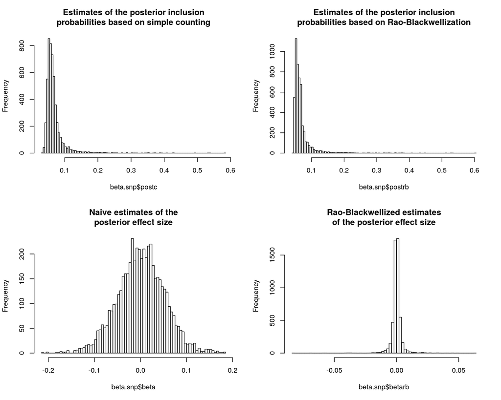

> Posterior inclusion probabilities

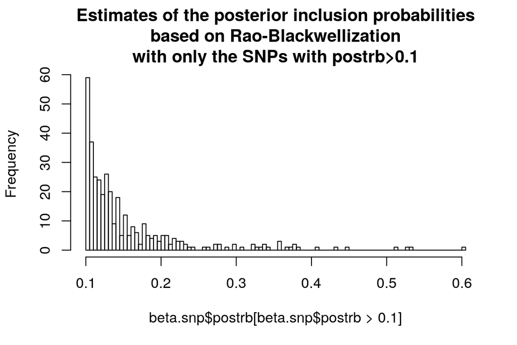

```r
beta.snp[abs(beta.snp$postrb)>0.4|abs(beta.snp$postrb)==0.4,]
```

```
##          chr  pos   postc  postrb     beta   betarb
## SNP_0968   0  759 0.58337 0.60382 -0.21227 -0.08242
## SNP_1451   0 1147 0.53643 0.53318  0.18197  0.06221
## SNP_1466   0 1160 0.42632 0.44608 -0.20185 -0.05676
## SNP_1467   0 1161 0.53333 0.52638 -0.20459 -0.06994
## SNP_2567   0 2081 0.40506 0.40610  0.17352  0.04555
## SNP_4893   0 4065 0.42744 0.43486  0.17967  0.04964
## SNP_4967   0 4133 0.49319 0.51175 -0.18138 -0.05961
```

> Posterior effect sizes

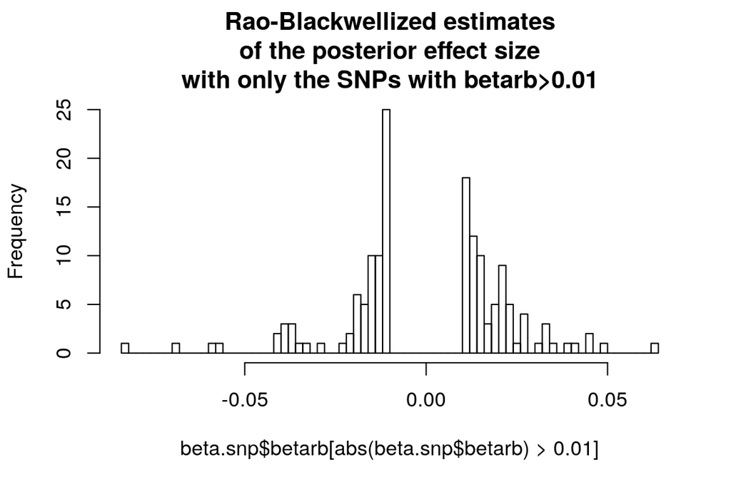

```r
beta.snp[abs(beta.snp$betarb)>0.05|abs(beta.snp$betarb)==0.05,]
```

```
##          chr  pos   postc  postrb     beta   betarb
## SNP_0968   0  759 0.58337 0.60382 -0.21227 -0.08242
## SNP_1451   0 1147 0.53643 0.53318  0.18197  0.06221
## SNP_1466   0 1160 0.42632 0.44608 -0.20185 -0.05676
## SNP_1467   0 1161 0.53333 0.52638 -0.20459 -0.06994
## SNP_4967   0 4133 0.49319 0.51175 -0.18138 -0.05961
```

### 2.3.2 Selecting rPEAS (betarb>0.006)

```r
# Snps associated with height
snps.h <- beta.snp[abs(beta.snp$betarb)>0.006|abs(beta.snp$betarb)==0.006,]
length(snps.h$chr)
```

```
## [1] 352
```

```r
# Snps positively associated with height
snps.h.pos <- row.names(snps.h[snps.h$betarb>0,])
length(snps.h.pos)
```

```
## [1] 175
```

```r
# Snps negatively associated with height
snps.h.neg <- row.names(snps.h[snps.h$betarb<0,])
length(snps.h.neg)
```

```
## [1] 177
```

```r
# Subset of alleles with positive effect on height
geno.snp.h.pos <- geno[row.names(geno) %in% snps.h.pos,]
geno.snp.h.pos[1:5,1:5]
```

```
##          ALT1 ALT10 ALT2 ALT3 ALT4
## SNP_0018    2     0    1    2    2
## SNP_0032    1     1    1    0    2
## SNP_0050    0     1    0    0    0
## SNP_0084    1     1    1    2    2
## SNP_0103    1     1    1    2    1
```

```r
# Subset of alleles with negative effect on height
geno.snp.h.neg <- geno[row.names(geno) %in% snps.h.neg,]
geno.snp.h.neg[1:5,1:5]
```

```
##          ALT1 ALT10 ALT2 ALT3 ALT4
## SNP_0001    1     0    0    0    0
## SNP_0010    1     1    0    0    0
## SNP_0082    0     0    0    0    0
## SNP_0104    1     1    1    0    1
## SNP_0112    1     1    1    0    1
```

```r
# Inverting 0 and 2 in the subset of alleles with negative effects,
# to only have alleles with a positive effect
snpnames <- row.names(geno.snp.h.neg)
geno.snp.h.neg <- geno.snp.h.neg %>%  mutate_if(is.integer, as.numeric) %>% mutate_all(list(~recode(., `0` = 2,`2`=0)))
row.names(geno.snp.h.neg) <- snpnames
geno.snp.h.neg[1:5,1:5]
```

```
##          ALT1 ALT10 ALT2 ALT3 ALT4
## SNP_0001    1     2    2    2    2
## SNP_0010    1     1    2    2    2
## SNP_0082    2     2    2    2    2
## SNP_0104    1     1    1    2    1
## SNP_0112    1     1    1    2    1
```

```r
# combining positive and negative alleles
geno.snp.h <-rbind(geno.snp.h.pos,geno.snp.h.neg)

df <- data.frame(clon=names(geno.snp.h),count_med_006=apply(geno.snp.h,2,sum,na.rm=T))

var(df$count_med_006)
```

```
## [1] 717.5155
```

```r
range(df$count_med_006)
```

```
## [1] 278 460
```

```r
mean(df$count_med_006)
```

```
## [1] 354.0421
```

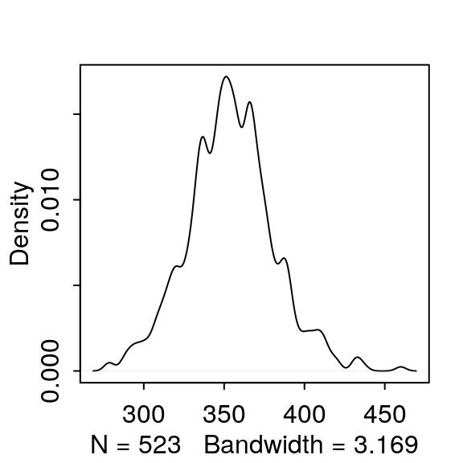

```r
rethinking::dens(df$count_med_006)
```

```r
DF <- merge(DF,df,by="clon")
head(DF)
```

```
##    clon count_all_006 count_all_350 count_fratl_006 count_fratl_350 count_ibatl_006 count_ibatl_350 count_med_006
## 1  ALT1           312           343             280             313             423             373           361
## 2 ALT10           295           322             297             330             409             358           360
## 3  ALT2           288           314             290             314             423             370           346
## 4  ALT3           316           340             266             293             413             364           361
## 5  ALT4           291           318             262             290             425             380           396
## 6  ALT5           314           343             305             330             428             382           353
```

### 2.3.3 Selecting rPEAs (first 350 SNPs)

```r
# Snps associated with height
beta.snp.order <- beta.snp[order(abs(beta.snp$betarb),decreasing=T),]
beta.snp.order350 <- beta.snp.order[1:350,]
length(beta.snp.order350$beta)
```

```
## [1] 350
```

```r
# Snps positively associated with height
snps.h.pos.350 <- row.names(beta.snp.order350[beta.snp.order350$betarb>0,])
length(snps.h.pos.350)
```

```
## [1] 174
```

```r
# Snps negatively associated with height
snps.h.neg.350 <- row.names(beta.snp.order350[beta.snp.order350$betarb<0,])
length(snps.h.neg.350)
```

```
## [1] 176
```

```r
# Subset of alleles with positive effect on height
geno.snp.h.pos.350 <- geno[row.names(geno) %in% snps.h.pos.350,]
geno.snp.h.pos.350[1:5,1:5]
```

```
##          ALT1 ALT10 ALT2 ALT3 ALT4
## SNP_0018    2     0    1    2    2
## SNP_0032    1     1    1    0    2
## SNP_0050    0     1    0    0    0
## SNP_0084    1     1    1    2    2
## SNP_0103    1     1    1    2    1
```

```r
# Subset of alleles with negative effect on height
geno.snp.h.neg.350 <- geno[row.names(geno) %in% snps.h.neg.350,]
geno.snp.h.neg.350[1:5,1:5]
```

```
##          ALT1 ALT10 ALT2 ALT3 ALT4
## SNP_0001    1     0    0    0    0
## SNP_0010    1     1    0    0    0
## SNP_0082    0     0    0    0    0
## SNP_0104    1     1    1    0    1
## SNP_0112    1     1    1    0    1
```

```r
# Inverting 0 and 2 in the subset of alleles with negative effects,
# to only have alleles with a positive effect
snpnames <- row.names(geno.snp.h.neg.350)
geno.snp.h.neg.350 <- geno.snp.h.neg.350 %>%  mutate_if(is.integer, as.numeric) %>% mutate_all(list(~recode(., `0` = 2,`2`=0)))
row.names(geno.snp.h.neg.350) <- snpnames
geno.snp.h.neg.350[1:5,1:5]
```

```
##          ALT1 ALT10 ALT2 ALT3 ALT4
## SNP_0001    1     2    2    2    2
## SNP_0010    1     1    2    2    2
## SNP_0082    2     2    2    2    2
## SNP_0104    1     1    1    2    1
## SNP_0112    1     1    1    2    1
```

```r
# combining positive and negative alleles
geno.snp.h.350 <-rbind(geno.snp.h.pos.350,geno.snp.h.neg.350)
names.med <- rownames(geno.snp.h.350)

df <- data.frame(clon=names(geno.snp.h.350),count_med_350=apply(geno.snp.h.350,2,sum,na.rm=T))

var(df$count_med_350)
```

```
## [1] 710.2197
```

```r
range(df$count_med_350)
```

```
## [1] 277 458
```

```r
mean(df$count_med_350)
```

```
## [1] 352.9751
```

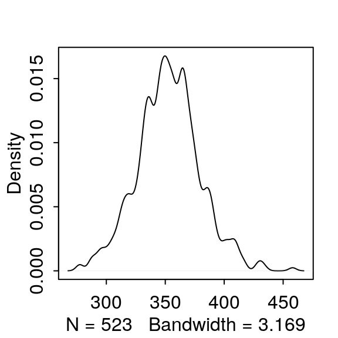

```r
rethinking::dens(df$count_med_350)
```

```r
DF <- merge(DF,df,by="clon")
DF
```

```
##      clon count_all_006 count_all_350 count_fratl_006 count_fratl_350 count_ibatl_006 count_ibatl_350 count_med_006 count_med_350
## 1    ALT1           312           343             280             313             423             373           361           361
## 2   ALT10           295           322             297             330             409             358           360           359
## 3    ALT2           288           314             290             314             423             370           346           345
## 4    ALT3           316           340             266             293             413             364           361           360
## 5    ALT4           291           318             262             290             425             380           396           395
## 6    ALT5           314           343             305             330             428             382           353           352
## 7    ALT6           296           322             288             316             431             382           351           351
## 8    ALT8           292           321             280             305             420             375           363           362
## 9    ALT9           284           302             259             287             421             372           369           368
## 10   ARM1           283           312             287             315             407             366           353           353
## 11  ARM10           310           339             283             310             427             381           361           360
## 12   ARM3           331           366             303             332             451             394           363           363
## 13   ARM4           299           328             288             320             441             388           366           366
## 14   ARM5           310           341             295             329             422             373           374           373
```

[output cut: 509 more lines]

```r
dim(DF)
```

```
## [1] 523   9
```

```r
sum(is.na(DF))
```

```
## [1] 0
```

# 3 Save all

```r
saveRDS(DF,file="../../data/CountPEAs.RDS")
```

# 4 Overlap between the 350 SNPs selected in each region

```r
length(setdiff(names.fr_atl,names.ib_atl))
```

```
## [1] 281
```

```r
length(setdiff(names.fr_atl,names.med))
```

```
## [1] 309
```

```r
length(setdiff(names.ib_atl,names.med))
```

```
## [1] 267
```

# References

Miguel, Marina de, Isabel Rodríguez-Quilón, Myriam Heuertz, Agathe Hurel, Delphine Grivet, Juan-Pablo Jaramillo-Correa, Giovanni G. Vendramin, et al. 2020. “Polygenic Adaptation and Negative Selection Across Traits, Years and Environments in a Long-Lived Plant Species (Pinus Pinaster Ait.).” *bioRxiv*, March. Cold Spring Harbor Laboratory, 2020.03.02.974113. doi:10.1101/2020.03.02.974113.